# Proposal

Cassie Malcom

Merly Klaas

Havisha Khurana

1/20/2022

```r
knitr::opts_chunk$set(warning = FALSE,
                      message = FALSE,
                      error = FALSE,
                      fig.width = 9,
                      fig.height = 9)
```

```r
pacman::p_load(edld652, tidyverse, psych, rio, here, forcats)
```

### Research Questions

**Theme – Underrepresented Populations**

1. How does student and teacher ethnicity vary by state in 2019 (latest year of data available)? Does this discrepancy affect student outcomes (graduation rates)? (RQ1)
- **Hypothesis:** Graduation rates for underrepresented students are better in states with higher teacher diversity.
2. Does COVID pandemic affect graduation rates for students by ethnicity? (Would need 2020 graduation rates along with COVID data - can we get access?) (RQ2)
3. Do some states prefer one sub-group over another based on how funds are alloted? Does a difference exist in the annual funding of schools that serve more underrepresented student population? We will use the Fiscal data by student demographic (race/ethnicity/FRLP status/ Disability/ ELL status?) by state/school district in 2018. (RQ3)

### Preliminary ideas (even hand sketches) of different visualizations

- For RQ1:, Mapping to US graphic by state for teacher/student ethnicity, and ELL status (this could be multiple maps of different teacher and student ethnicity; ELL could be another categorical variable)
  - Maps could have dot plots representing raw counts, or proportions on a continuous scale. Some examples-
    - Source: [demographics.coopercenter.org](https://demographics.coopercenter.org/racial-dot-map)

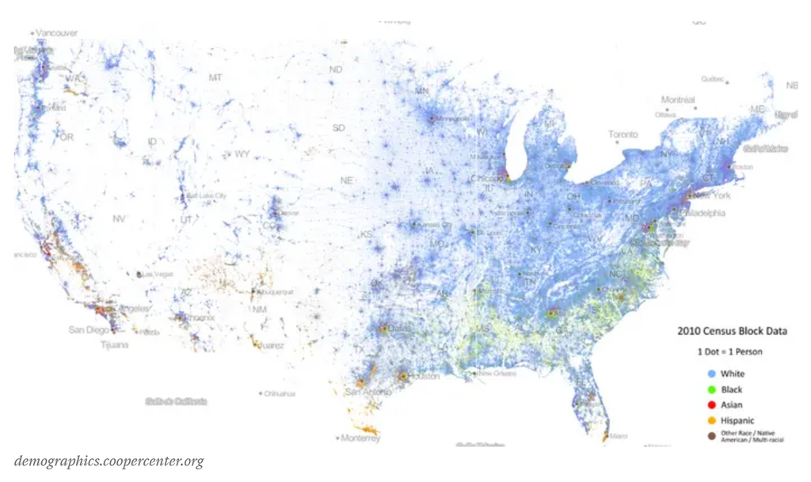

- Source: [census.gov](https://www.census.gov/newsroom/blogs/random-samplings/2021/08/measuring-racial-ethnic-diversity-2020-census.html)

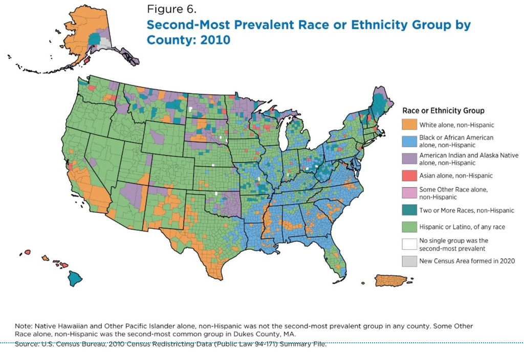

- For graduation rates, can use dumbbell plot to show the difference in some major groups for each state - For RQ2: Timeline or scale of pre- vs. post-COVID graduation rates by ethnicity - Tables or line graphs, dumbbell plot - For RQ3: Still thinking how to unpack the information from the datasets, and what variable to focus on. - General overview of website design/dashboard: three tabs for each questions

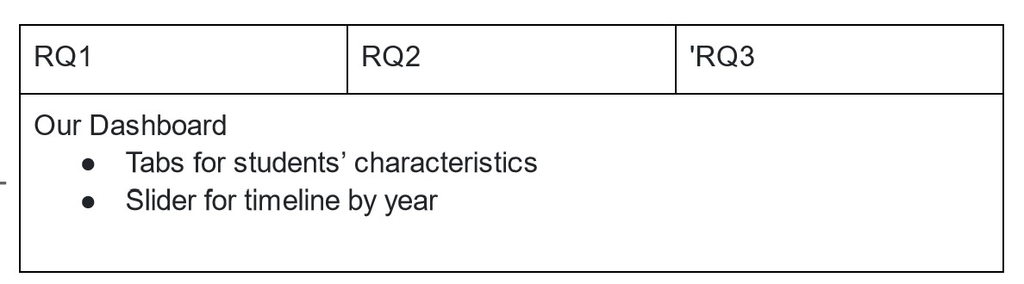

Figure 3 - Overview of website

### Some documentation that you have played with the course data some

```r
grad_rates <- get_data("EDFacts_acgr_lea_2011_2019")
```

Reusing the code from walkthrough here to clean grad-rates.

```r
grad_rates <- grad_rates %>%
  tidyr::separate(ALL_RATE, c("lower", "upper"), sep = "-") %>%
  filter(!grepl("G|L|P", lower)) %>%
  mutate(
    upper = ifelse(is.na(upper), lower, upper),
    lower = as.numeric(lower),
    upper = as.numeric(upper)
  ) %>%
  rowwise() %>%
  mutate(mean = mean(c(lower, upper))) %>%
  ungroup()
```

**Descriptive Statistics**

Descriptive statistics for the varable “mean”, which is the mean graduation rate per school district

```r
 describe(grad_rates$mean)
```

```
##    vars    n  mean    sd median trimmed   mad min max range  skew kurtosis   se
## X1    1 8056 80.07 14.55   84.5   82.52 11.12   2  98    96 -2.05     5.35 0.16
```

**Histogram**

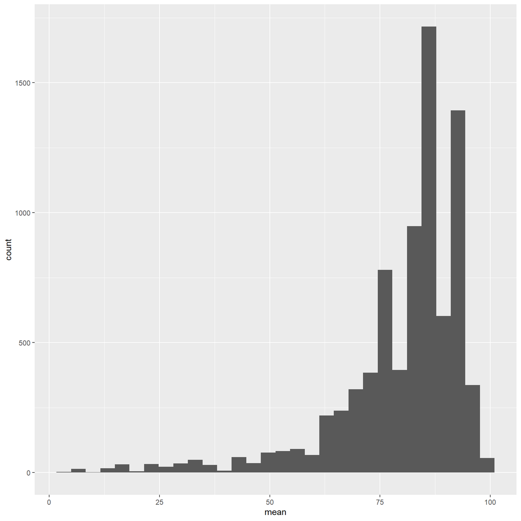

```r
ggplot(grad_rates, aes(x = mean)) +
geom_histogram()
```

**Teacher and student ethnic diversity**

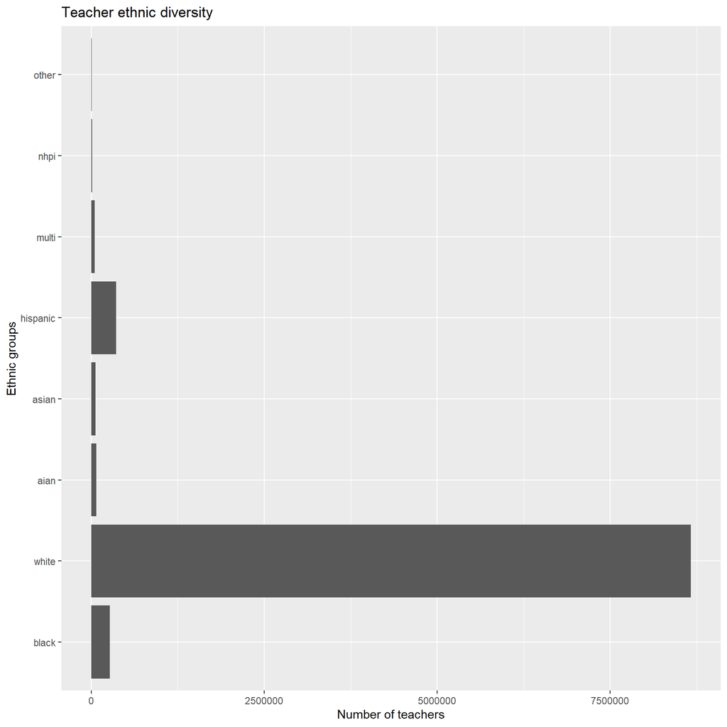

```r
race <- import(here("data", "teacher_student_race_ethnicity.csv" )) %>%
  mutate(State = ST) %>%
  select(-c(ST, totalS, totalT, ends_with("N"))) %>%
  pivot_longer(cols = ends_with("T"),
               names_to = "teacher_race",
               values_to = "pctracet") %>%
  pivot_longer(cols = ends_with("S"),
               names_to = "student_race",
               values_to = "pctraces")

race$teacher_race <-gsub("T","",as.character(race$teacher_race))
race$student_race <-gsub("S","",as.character(race$student_race))

teacher.race <- race %>%
  select(teacher_race, pctracet) %>%
  ggplot(aes(pctracet,fct_reorder(teacher_race, pctracet)))+
  geom_col() +
    labs(title = "Teacher ethnic diversity",
         x = "Number of teachers",
         y = "Ethnic groups")


teacher.race
```

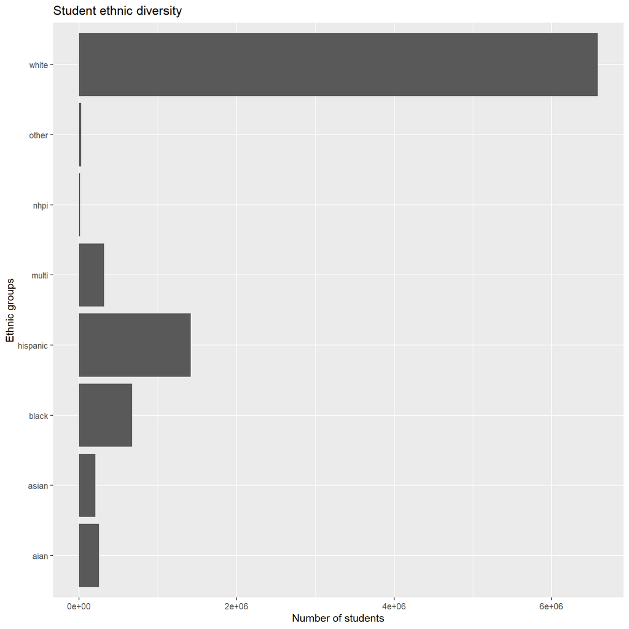

```r
stu.race <- race %>%
  select(student_race, pctraces) %>%
  ggplot(aes(pctraces,student_race))+
  geom_col()+
        labs(title = "Student ethnic diversity",
         x = "Number of students",
         y = "Ethnic groups")
stu.race
```

### Names of the datasets you’re thinking of using and what keys you’ll need for joining the data

- Key: LEAID for key (or possibly district name)
- NCES_CCD_nonfiscal_district_2017_2021_membership for student proportion by ethnicity
- EDFacts_acgr_lea_2011_2019 - Graduation rates by school district and state
- Teacher proportion by ethnicity: still finding. Some options
  - This git repo on [teacher diversity](https://github.com/WPMedia/teacher_diversity) This public GitHub provides teacher ethnicity by state and school district, which we might be able to join with the class data set. Data from 2017-2018 for most schools and for 2016-2017 for a few. Data on 6 states is not reported.
- Covid data: stiff finding. Some options
  - This [paper](https://jsri.msu.edu/publications/nexo/vol/no-2-spring-2021/racial-ethnic-differences-in-education-disruptions-during-the-covid-19-pandemic) might provide a source.
- Fiscal data for the most recent year (2018).

### Identification of the intended audience for each visualization

- We plan to make each/most visualizations for different audience, including general (public), policy makers, and researchers.
- For general public and policy makers, we want to make easy to understand visuals and will have no to very few statistics.
- For researchers, we’d like to include those statistics as well as tables.

### The intended message to be communicated for each plot.

- Differences in graduation rates for underrepresented student populations by various factors
- Showcasing where inequity for students may be an issue
- R3 to show how the fiscal year varies by students’ characteristics. Do states perpetuate some systematic bias?